# An Analysis of A/B Test Results

## by Jeffrey Van Anderson

## Overview of A/B Testing

In order analyze an experiment in way that determines whether or not there is any statistical significance, a useful scientific method is the A/B test. In order to carry out this type of experiment objectively, it is integral that there is an attempt to disprove the effectiveness of the treatment group. In turn, there is a "null" hypothesis that states there is no statistical difference from the contol group for the treatment group. Additionally, the alternitave hypothesis states that there is a statistically significant difference. The point of A/B testing is to prove the null hypothesis, and if this fails, then the alternative hypothesis is excepted.

## Scenario

In this hypothetical scenario, a simple data set of two web pages for an e-commerce website are analyzed. With a new webpage tested as a treatment group, and the old webpage as the control group, the company wants to know whether or not the new web page increases the "conversion" rate. The conversion rate is the proportion of website users that buy the companies product.

In order to test the new page for statistical significance in a realiable and scientific way, the results must be tested against the possibility of random distibution in results. The following demonstrates how this type of test can be performed using a bootstrapped simulation in python.

## Observed Test Results

Prior to any statistical analysis, there appears to be a slightly worse conversion rate for the tratment group than the control group. The results are as follows:

| Group | Conversion Rate |
| --- | --- |
| Both | 11.96% |
| Treatment | 11.88% |
| Control | 12.04% |

## Simulation

The following histogram shows the distribution of simulated differences as compared to the observed difference in conversion rates.

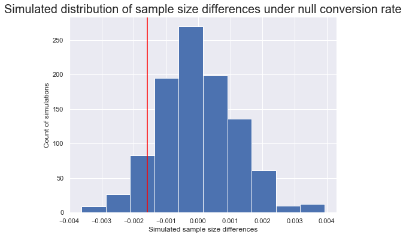

```python
#for ease of visualization, the obseved difference is plotted as an x intercept red line over the previously calculated
#normal distribution
plt.figure(figsize=(8,6))
plt.hist(p_diffs)
plt.title('Simulated distribution of sample size differences under null conversion rate', fontsize=20)
plt.xlabel('Simulated sample size differences', fontsize=12)
plt.ylabel('Count of simulations', fontsize=12)
plt.axvline(x=obs_diff, color='red');
```

## Interpreting the Simulated Results

Noting that the verticle red line in the previous histogram is the observed difference in simulated results, a p-value of the observed difference under the null hypothesis is around 0.90. In other words, it is extremely likely that the control page has at least the conversion rate of the treatment page. Typically, a p-value that disproves a null hypothesis is below 0.05 depending on the the data.

## Why Hypothesis Test?

Although it may seam easy to infer that the treatment page is not effective from the observed data, this is merely a guess without additional analysis. The use of inferential statistics help remove some of the guess work from data analysis.